# CE083 - Estatística Computacional I

GABARITO

Dezembro, 2016

# Exercício: inferência

## Introdução

Um artigo publicado na revista [Technometrics](http://amstat.tandfonline.com/loi/tech), de SC Narula, e JF Wellington (*Prediction, linear regression, and a minimum sum of relative errors*), apresenta dados de preços de vendas e taxas anuais para 24 casas.

## Dados

Os dados do artigo mencionado estão disponíveis em

```r
url <- "http://www.leg.ufpr.br/~fernandomayer/dados/montgomery_11-4.txt"
```

Com isso:

- Faça a importação dos dados, verifique sua estrutura e faça um sumário estatístico.

```r
url <- "http://www.leg.ufpr.br/~fernandomayer/dados/montgomery_11-4.txt"
dados <- read.table(url, header = TRUE)
str(dados)
```

```
## 'data.frame':    24 obs. of  2 variables:
##  $ Venda: num  25.9 29.5 27.9 25.9 29.9 29.9 30.9 28.9 35.9 31.5 ...
##  $ Taxas: num  4.92 5.02 4.54 4.56 5.06 ...
```

```r
summary(dados)
```

```
##      Venda           Taxas
##  Min.   :25.90   Min.   :3.891
##  1st Qu.:29.90   1st Qu.:5.057
##  Median :33.70   Median :5.974
##  Mean   :34.61   Mean   :6.405
##  3rd Qu.:38.15   3rd Qu.:7.873
##  Max.   :45.80   Max.   :9.142
```

- Faça um gráfico apropriado para relacionar o preço de vendas às taxas pagas (o preço de venda varia conforma as taxas, ou seja, o preço é a variável dependente).

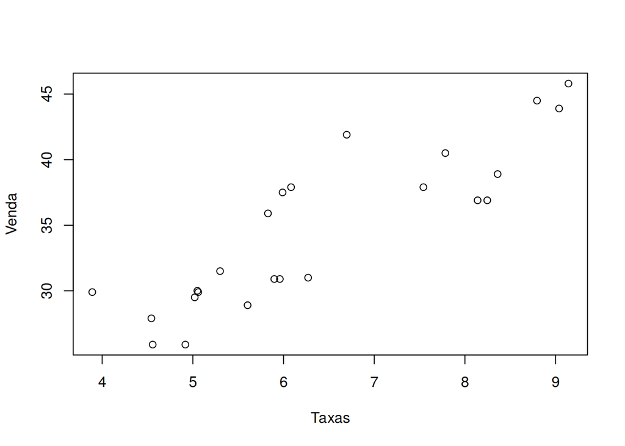

```r
plot(Venda ~ Taxas, data = dados)
```

## Ajustando um modelo linear

Um **modelo linear** entre duas variáveis $X$ e $Y$, é definido matematicamente como uma equação com dois parâmetros desconhecidos,

$$Y = \beta_0 + \beta_1 X$$

Assim, dados $n$ pares de valores, $(X_1, Y_1), (X_2, Y_2), \ldots, (X_n, Y_n)$, se for admitido que $Y$ é função linear de $X$, pode-se estabelecer uma regressão linear simples, cujo modelo estatístico é

$$Y_i = \beta_0 + \beta_1 X_i + e_i, \quad i = 1, 2, \ldots, n$$

Como através de uma amostra obtemos uma estimativa da verdadeira equação de regressão, denominamos

$$\hat{Y}_i = \hat{\beta}_0 + \hat{\beta}_1 X_i$$

ou seja, $\hat{Y}_i$ é o valor **estimado** de $Y_i$, através das **estimativas** de $\beta_0$ e $\beta_1$, que chamaremos de $\hat{\beta}_0$ e $\hat{\beta}_1$. Para cada valor de $Y_i$, temos um valor $\hat{Y}_i$ estimado pela equação de regressão,

$$Y_i = \hat{Y}_i + e_i$$

Portanto, o erro (ou desvio) de cada observação em relação ao modelo adotado será

$$\begin{align}
e_i &= Y_i - \hat{Y}_i \\
e_i &= Y_i - (\beta_0 + \beta_1 X_i)
\end{align}$$

Comumente se assume que os erros possuem uma distribuição normal com média zero e variância constante, ou seja, $e_i \sim \text{N}(0, \sigma^2)$.

Através da **solução de mínimos quadrados**, obtemos as expressões para estimar os parâmetros $\beta_0$ e $\beta_1$:

$$\begin{align}
\hat{\beta}_1 &= \frac{\sum_{i=1}^{n} X_iY_i - \frac{\sum_{i=1}^{n}
X_i \sum_{i=1}^{n} Y_i}{n}}{\sum_{i=1}^{n}X_i^2 -
\frac{(\sum_{i=1}^{n} X_i)^2}{n}} \\
& \\
\hat{\beta_0} &= \bar{Y} - \hat{\beta}_1 \bar{X}
\end{align}$$

onde

$$\begin{align}
\bar{Y} = \frac{1}{n} \sum_{i=1}^{n} Y_i \qquad \text{e} \qquad
\bar{X} = \frac{1}{n} \sum_{i=1}^{n} X_i
\end{align}$$

Como vimos pelas soluções acima, primeiro calculamos $\hat{\beta_1}$, e depois $\hat{\beta_0}$. Para facilitar as contas, vamos criar objetos `X` e `Y` com as colunas `Venda` e `Taxa` (saber quem é `X` e quem é `Y` faz parte da interpretação do problema), e `n` que é o tamanho da amostra

```r
## Defina X, Y, e n
X <- dados$Taxas
Y <- dados$Venda
n <- length(X)
```

Agora calculamos $\hat{\beta_1}$ com

```r
## Crie um objeto chamado beta1
beta1 <- (sum(X * Y) - (sum(X) * sum(Y))/n)/(sum(X^2) - (sum(X)^2/n))
beta1
```

```
## [1] 3.324371
```

E $\hat{\beta_0}$ é calculado com

```r
## Crie um objeto chamado beta0
beta0 <- mean(Y) - beta1 * mean(X)
beta0
```

```
## [1] 13.32018
```

Para conferir os seus cálculos e prosseguir com a análise, ajuste um modelo linear entre as duas variáveis consideradas, usando a função `lm()`, e verifique se os coeficientes estimados pela função são os mesmos que você calculou à mão.

```r
## Crie um objeto chamado mod com o modelo ajustado
mod <- lm(Venda ~ Taxas, data = dados)
mod
```

```
##
## Call:
## lm(formula = Venda ~ Taxas, data = dados)
##
## Coefficients:
## (Intercept)        Taxas
##      13.320        3.324
```

Para avaliar a significância do modelo, podemos realizar uma **Análise de Variância** (ANOVA) para a regressão. Como vimos na estimação dos parâmetros, o objetivo é encontrar parâmetros que façam com que a soma de quadrados dos resíduos seja mínima. Podemos particionar a soma de quadrados da seguinte forma:

$$SQTot = SQMod + SQRes$$

Portanto, se um modelo é bem ajustado, esperamos que a soma de quadrados do modelo $SQMod$ seja grande, e a $SQRes$ sejá mínima. Um quadro de ANOVA para o modelo irá testar, através de um teste F, se a soma de quadrados do modelo é significativamente diferente de zero. Para fazer essa ANOVA, usamos a função `anova()`

```r
## Quadro de Análise de Variância
anova(mod)
```

```
## Analysis of Variance Table
##
## Response: Venda
##           Df Sum Sq Mean Sq F value    Pr(>F)
## Taxas      1 636.16  636.16  72.556 2.051e-08 ***
## Residuals 22 192.89    8.77
## ---
## Signif. codes:  0 '***' 0.001 '**' 0.01 '*' 0.05 '.' 0.1 ' ' 1
```

Uma parte importante em uma análise de regressão linear é a verificação dos resíduos do modelo, ou seja, os desvios de cada valor observado $Y$ em relação aos valores **preditos** pelo modelo, $\hat{Y}$. Como vimos que a suposição do modelo é de que os resíduos possuam uma distribuição normal com média 0 e variância constante, $e_i \sim \text{N}(0, \sigma^2)$, então podemos verificar essa suposição fazendo um histograma destes resíduos. Para isso, podemos extrair os resíduos diretamente do objeto `mod` com a função `residuals()`, e fazer o histograma destes resíduos

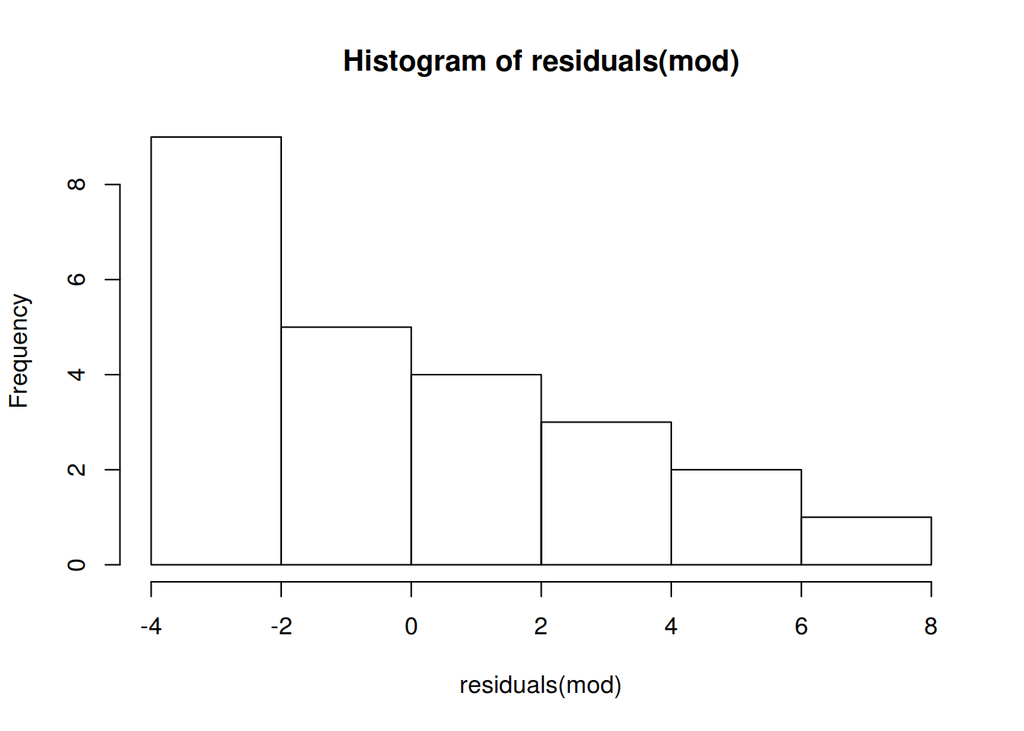

```r
## Faça um histograma dos resíduos do modelo
hist(residuals(mod))
```

Ainda com o objeto `mod`, podemos ajustar o modelo graficamente ao gráfico da relação entre `Venda` e `Taxas`. Para isso, usamos uma função `abline()`, utilizada para inserir linhas em gráficos.

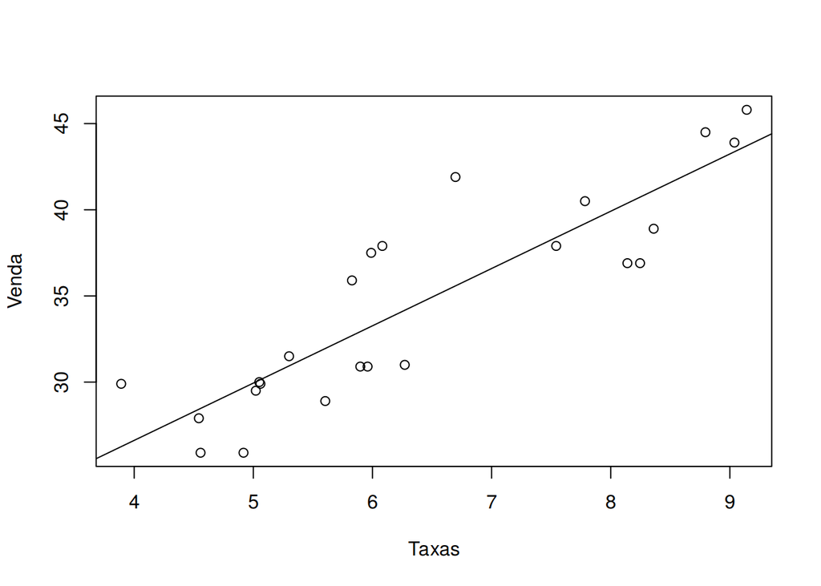

```r
## Faça o gráfico da relação entre Taxa e Vendas, e insira a linha do
## modelo com abline()
plot(Venda ~ Taxas, data = dados)
abline(mod)
```

Com os resultados que você obteve acima, responda:

1. Existe uma relação significativa entre preço de venda e taxas? Se sim, de que tipo (positiva, negativa)? **Resposta**: *Sim, existe uma relação que é positiva, pois o sinal do coeficiente angular, $\beta_1 = 3.3243712$, é positivo. Além disso, como a soma de quadrados do modelo foi significativa (pela tabela da ANOVA), então podemos dizer que a relação é significativa.*
2. Pelo resultado da ANOVA, o modelo pode ser considerado significativo (ou seja, uma variável pode ser explicada pela outra)? **Resposta**: *sim, pela tabela da ANOVA, o modelo é significativo (a soma de quadrados do modelo é significativamente diferente de zero).*
3. Através do histograma dos resíduos, pode-se dizer que os pressupostos do modelo foram atendidos (ou seja, os resíduos possuem uma distibyuição normal com média em torno do zero)? **Resposta**: *pelo histograma dos resíduos visto acima, vemos que os pressupostos não foram atendidos, pois a distribuição não é simétrica em torno do zero.*

## Inferência sobre a média de vendas

Sabemos que o intervalo de confiança para média de uma distribuição normal com variância desconhecida, para uma amostra de tamanho $n$ é dado por:

$$\left(\bar{x} - t_t \sqrt{\frac{s^2}{n}} \quad, \quad
\bar{x} + t_t \sqrt{\frac{s^2}{n}} \right)$$

onde $t_t$ é o quantil de ordem $1-\alpha/2$ da distribuição $t$ de Student, com $n-1$ graus de liberdade.

Considerando que estamos interessados em obter um intervalo de confiança para a média de `Vendas`, faça o que se pede:

- Calcule o tamanho da amostra, a média e a variância amostral da coluna `Vendas`

```r
## Tamanho da amostra (n), média e variância de Venda
n <- length(dados$Venda)
n
```

```
## [1] 24
```

```r
t.m <- mean(dados$Venda)
t.m
```

```
## [1] 34.6125
```

```r
t.v <- var(dados$Venda)
t.v
```

```
## [1] 36.04549
```

- Monte o intervalo de confiança utilizando os quantis da distribuição $t$, para obter um IC de 95% de confiança.

```r
## IC com 95% de confiança
t.ic <- t.m + qt(c(0.025, 0.975), df = n - 1) * sqrt(t.v/n)
t.ic
```

```
## [1] 32.07732 37.14768
```

Além do intervalo de confiança, podemos realizar um teste de hipótese para testar se a média de vendas é igual a determinado valor. Os procedimentos gerais para este teste de hipótese são:

1. Definir a hipótese nula ($H_0$) e a alternativa ($H_1$)
2. Definir um nível de **significância** $\alpha$ (ex.: $\alpha = 0,05$), que irá determinar o nível de **confiança** $100(1-\alpha)\%$ do teste
3. Determinar a **região de rejeição** com base no nível de significância $\rightarrow$ valor crítico
4. Calcular a **estatística de teste**, sob a hipótese nula
   $$t_{calc} = \frac{\bar{x} - \mu_0}{s/\sqrt{n}}$$
5. Rejeitar a hipótese nula se a estatística de teste calculada estiver dentro da região de rejeição ($|t_{calc}| > |t_{crit}|$)

Portanto, se desejamos testar a hipótese de que o preço médio de venda é igual 35, temos as seguintes hipóteses:

$$\begin{align}
\text{H}_0: \mu = 35 \\
\text{H}_1: \mu \neq 35 \\
\end{align}$$

Usando um nível de significância $\alpha = 0,05$, realize este teste de hipótese passo-a-passo, calculando: o valor crítico de $t$, o valor de $t$ calculado, e o p-valor do teste.

```r
## Valor de alpha
alpha <- 0.05
## Valor crítico de t
tcrit <- abs(qt(alpha/2, df = n - 1))
tcrit
```

```
## [1] 2.068658
```

```r
## Estatística de teste
tcalc <- (mean(dados$Venda) - 35)/(sd(dados$Venda)/sqrt(n))
tcalc
```

```
## [1] -0.3161927
```

```r
## tcalc > tcrit?
tcalc > tcrit
```

```
## [1] FALSE
```

```r
## Calculano o p-valor
## Note que essa probabilidade deve ser multiplicada por 2, pois a
## função pt() só calcula uma cauda, e o teste é bicaudal
pt(abs(tcalc), df = n - 1, lower.tail = FALSE) * 2
```

```
## [1] 0.7547079
```

Use a função `t.test()` para conferir os cálculos que você realizou acima.

```r
t.test(dados$Venda, mu = 35)
```

```
##
##  One Sample t-test
##
## data:  dados$Venda
## t = -0.31619, df = 23, p-value = 0.7547
## alternative hypothesis: true mean is not equal to 35
## 95 percent confidence interval:
##  32.07732 37.14768
## sample estimates:
## mean of x
##   34.6125
```

Qual a sua conclusão a respeito do teste de hipótese? **Resposta**: *como o p-valor do teste de hipótese foi $0.7547079 > 0,05$, então não podemos rejeitar a hipótese nula, ou seja, não rejeitamos a hipótese de que a média de vendas seja igual a 35.*